# Uber Analytics

Project Report for STAT 303-1 Fall 2025

Author

Dawson Loo

Published

December 9, 2025

Abstract

In this report, we explore a ride-sharing dataset to determine which factors most strongly correlate with customer ratings. By analyzing variables such as vehicle type, ride duration, and booking value, we aim to provide insights that can help improve customer satisfaction in the ride-sharing industry. Over 25% of rides are cancelled by both drivers and customers, and so we will investigate the reasons and what factors lead to these cancellations.

## 1) Introduction/Inspiration

Growing up in the San Francsico Bay Area, I’ve watched as the region became the birthplace of many technologically groundbreaking companies. A huge industry that was a part of this explosion was the reinvention of the taxi. By experience, public transportation isn’t the most accessible so rideshares just made sense. Companies such as Uber and Lyft were founded here nad it has become the testing ground for many autonomous vehicle research companies such as Zoox and Waymo. Not only did I have an internship in high school that was around researching autonomous vehicle trends, but now with collegiate knowledge in data science practice, I think this research project is worth exploring once again in a deeper level.

## 2) Problem Statements

1. What factors most strongly influence ride cancellations (by both customers and drivers)?
2. How do different variables correlate to customer satisfaction (ratings)?

## 3) Data

This data is provided by Kaggle Datasets.

Link: https://www.kaggle.com/datasets/yashdevladdha/uber-ride-analytics-dashboard

The dataset includes over 150000 observations and 21 unique variables.Each observation represents a single uber request and includes:

1. **Date** and **Time**
2. **Booking ID**
3. **Booking Status** (No Driver Found, Incomplete, Completed, Cancelled by Driver, Cancelled by Customer)
4. **Customer ID**
5. **Vehicle Type** (eBike, Go Sedan, Auto, Premier Sedan, Bike, Go Mini, Uber XL)
6. **Pickup** and **Dropoff** Location
7. **Customer Wait Time**
8. **Trip Duration** (in minutes)
9. **Customer-initiated cancellation** and **Reason**
10. **Driver0initiated cancellation** and **Reason**
11. **Ride Completion** and **Reason**
12. **Ride Fare**
13. **Ride Distance**
14. **Driver** and **Customer** Ratings (1-5 Scale)
15. **Payment Method** (UPI, Debit Card, Cash, Uber Wallet, Credit Card)

In this dataset, there are 4 continuous numeric variables, 2 ordinal categorical variables, 12 nominal variables, and 3 binary (yes, no) variables. We will be using all except the payment method and location.

## 4) Stakeholders

My stakeholders of this project will include any Uber or rideshare company interested in understanding these trends to optimize their operations and improve customer satisfaction. This can also be helpful to any local govenrnment agencies who might want this data for future urban planning. Lastly, this can be beneficial to any investors looking at investment opportunities in the rideshare space.

## 5) Data Cleaning

Before we dive in, it’s important that I note that this dataset will include a lot of null values, but they don’t indicate that the information is missing. For example, here is a view of the first 5 rows:

|  | Date | Time | Booking ID | Booking Status | Customer ID | Vehicle Type | Pickup Location | Drop Location | Avg VTAT | Avg CTAT | ... | Customer Cancellation Reason | Driver Cancelled | Driver Cancellation Reason | Incomplete Rides | Incomplete Rides Reason | Booking Value | Ride Distance | Driver Ratings | Customer Rating | Payment Method |
| --- | --- | --- | --- | --- | --- | --- | --- | --- | --- | --- | --- | --- | --- | --- | --- | --- | --- | --- | --- | --- | --- |
| 0 | 2024-03-23 | 2025-12-09 12:29:38 | "CNR5884300" | No Driver Found | "CID1982111" | eBike | Palam Vihar | Jhilmil | NaN | NaN | ... | NaN | NaN | NaN | NaN | NaN | NaN | NaN | NaN | NaN | NaN |
| 1 | 2024-11-29 | 2025-12-09 18:01:39 | "CNR1326809" | Incomplete | "CID4604802" | Go Sedan | Shastri Nagar | Gurgaon Sector 56 | 4.9 | 14.0 | ... | NaN | NaN | NaN | 1.0 | Vehicle Breakdown | 237.0 | 5.73 | NaN | NaN | UPI |
| 2 | 2024-08-23 | 2025-12-09 08:56:10 | "CNR8494506" | Completed | "CID9202816" | Auto | Khandsa | Malviya Nagar | 13.4 | 25.8 | ... | NaN | NaN | NaN | NaN | NaN | 627.0 | 13.58 | 4.9 | 4.9 | Debit Card |
| 3 | 2024-10-21 | 2025-12-09 17:17:25 | "CNR8906825" | Completed | "CID2610914" | Premier Sedan | Central Secretariat | Inderlok | 13.1 | 28.5 | ... | NaN | NaN | NaN | NaN | NaN | 416.0 | 34.02 | 4.6 | 5.0 | UPI |
| 4 | 2024-09-16 | 2025-12-09 22:08:00 | "CNR1950162" | Completed | "CID9933542" | Bike | Ghitorni Village | Khan Market | 5.3 | 19.6 | ... | NaN | NaN | NaN | NaN | NaN | 737.0 | 48.21 | 4.1 | 4.3 | UPI |

5 rows × 21 columns

Notice that for most of the NaN values, it isn’t indicating that data is lost. Logically, these NaN’s are determined by ride completion/incompletion or simply yes/no valuation.

### a) Cleaning - Ride Cancellations Data

Question to answer: What factors most strongly influence ride cancellations (by both customers and drivers)?

An incomplete ride doesn’t necessarily indicate that the ride was cancelled by the customer or driver. For example, the car could have broke down or other issues occured. Therefore, we will not use Ride Completion and its Reason as a factor in this analysis. The customer and driver cancellation variables are OH encoded, so 1 indicates it is cancelled and Null indicated it wasn’t. Handily, we can see that for every cancellation there is a given reason, Therefore, we don’t have any missing data about cancellation.

The reasons are categorized into 5 categories:

- Customer Reason: ‘Driver is not moving towards pickup location’,‘Driver asked to cancel’, ‘AC is not working’, ‘Change of plans’,‘Wrong Address’
- Driver Reason: ‘Personal & Car related issues’, ‘Customer related issue’,‘More than permitted people in there’, ‘The customer was coughing/sick’

Note: One of the categories for reasons of customer cancellation is that the driver asked to cancel. Therefore we should count that as a driver cancellation.

We are also going to analyze this data over time and date, which all observations include.

For vehicle type, it wouldn’t make sense to analyze bike and Ebike cancellations, so we can disregard those two categories in the data. This finalizes our dataset with 11,710 customer cancellations, 17,508 driver cancellations, and a total observation count of 116,926.

### b) Cleaning - Customer Ratings Data

Question to answer: Which variables most strongly correlate with customer ratings?

To clean this data, we are going to pull all the variables that we can correlate with customer ratings. This includes date, time, vehicle type, pickup duration, ride duration, booking value, and ride distance. We will also drop any row that doesn’t include a customer rating because it can skew the data by including any information from incomplete rides, removing 57,000 null customer rating.

Vehicle type may be a very important factor, therefore to turn the categorical variable correlatable, we will one-hot encode them. These vehicle types include eBike, Go Sedan, Auto, Premier Sedan, Bike, Go Mini, and Uber XL.

Overall, this will reduce our dataset to 93,000 valid observations.

## 6) Data Analysis

### a) What factors most strongly influence ride cancellations (by both customers and drivers)?

```
                                              count
Customer Cancellation Reason
Change of plans                                1783
Wrong Address                                  1775
Driver is not moving towards pickup location   1765
Driver asked to cancel                         1724
AC is not working                              1155
                                     count
Driver Cancellation Reason
Customer related issue                5335
Personal & Car related issues         5232
The customer was coughing/sick        5232
More than permitted people in there   5217
```

Strictly by count, there were more cancellations executed by drivers than customers, but looking closer, we can see that one of the customer cancellation reasons is that the driver asked to cancel. This also goes with the driver cancellation reasons where the customer was sick. Correcting the reasons to the right person, we get:

```
                              count
Customer Cancellation Reason
Sick or Health Issue           5232
Change of plans                1783
Wrong Address                  1775
Driver not moving to pickup    1765
AC not working                 1155
                                     count
Driver Cancellation Reason
Customer related issue                5335
Personal & Car related issues         5232
More than permitted people in there   5217
Driver asked to cancel                1724
```

Previously, 7% of rides were cancelled by customers and 18% by drivers. Now, 10% is from customers and 15% are fromm drivers. This is properly showing the cancelled ride causation by driver and customer. Next, it would be valuable to see when these cancellations occur throughout the day. But simply plotting the count of cancellations per hour isn’t going to be of any use since there is going to be more ride requests during the day compared to at night. Instead, we must compare by proportion of cancellations to total rides per hour. Getting us these charts:

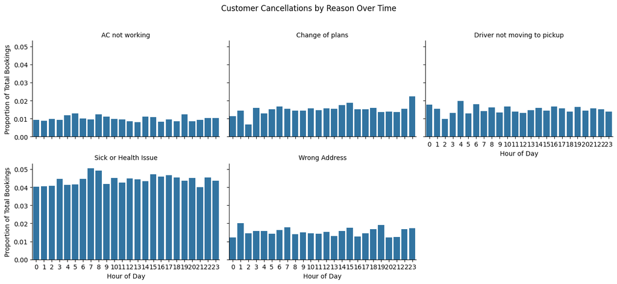

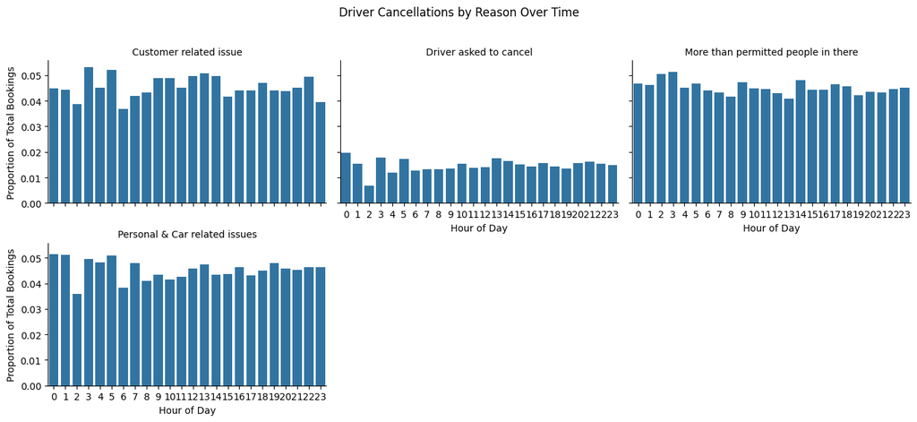

In terms of their relation to time, we can see that the proportions are fairly constant throughout the day, only fluctuating by around 1% each. Therefore it isn’t likely that time of affects the rate of cancellation. But with the cancellation reasoning adjustments we made earlier, we can now see these proportions of cancellations more accurately, for each reason, and by hour.

Another note is that drivers will also cancel rides when there are too many people permitted in the vehicle, so one can argue that this is a customer cancellation. For the category of “customer related issue” however, we cannot say if this is a a problem caused by the driver or customer, and so swapping it to a customer cancellation wouldn’t make sense. Therefore, the two highest customer cancellation reasons are sicknesses and underbooking, whereas the two highest driver cancellation reasons are personal & car related or a customer related issue.

### b) Which variables most strongly correlate to customer ratings of drivers and how does time affect it?

Understanding the factors that influence customer ratings is essential for maintaining a high-quality customer experience for the company. In this analysis, we investigate which variables show the strongest correlation with customer ratings of drivers—such as trip characteristics, vehicle types, and how it all looks over time.

To start, we will get the correlation of each metric in our dataset:

```
                            Correlation with Customer Rating
Customer Rating                                     1.000000
Vehicle Type_Go Sedan                               0.005779
Ride Distance                                       0.004514
Ride Duration                                       0.001000
Vehicle Type_Uber XL                                0.000107
Booking Value                                      -0.000287
Vehicle Type_Go Mini                               -0.000327
Vehicle Type_eBike                                 -0.000396
Vehicle Type_Bike                                  -0.000620
Vehicle Type_Premier Sedan                         -0.000955
Driver Ratings                                     -0.001010
Time                                               -0.002283
Date                                               -0.002467
Vehicle Type_Auto                                  -0.003399
Pickup Duration                                    -0.003945
```

Our next way of analyzing customer ratings is through time. Not only can we visualize its change over time, but we can group them into the different vehicle categories. The two diagrams below show the average customer ratings over time.

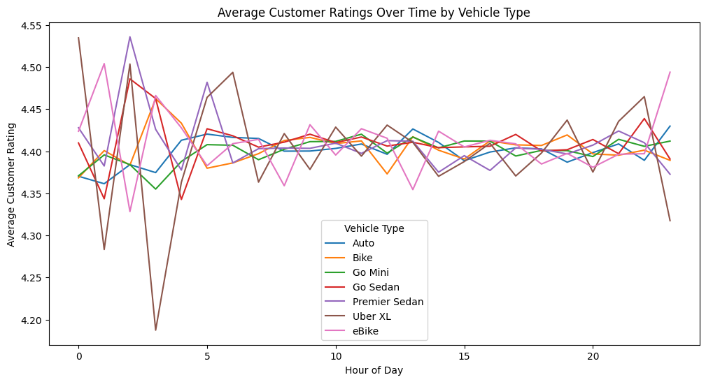

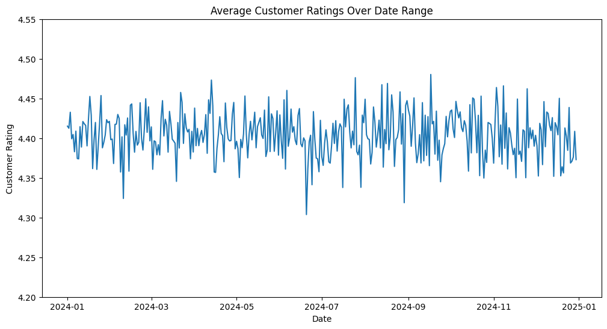

In the first graph, we are visualizing the average customer rating per hour of the day for each vehicle type. Interestingly, between the hours of 12am and 5am, the trends are much more chaotic compared to the rest of the day. For example, UberXL is seen starting at midnight with a max 4.54 average rating, then dropping to a 4.19 average by 3am. In contrast to mid-day, it only deviates by around 5 points from 8am-8pm. There can be many reasons to this, but the most plausible explanations relate to overall demand. The graph below shows the overall demand of rides for each hour of the day, and UberXL’s are consistently the lowest requested, therefore individual rides have a larger impact on the hourly average.

In the second, we are visualizing the same average rating per day of the entire year. Unlike the hourly view—where short-term fluctuations are prominent—daily averages display a much smoother and more stable pattern. Most days hover within a narrow rating band, indicating that customer satisfaction remains consistent over longer time intervals.

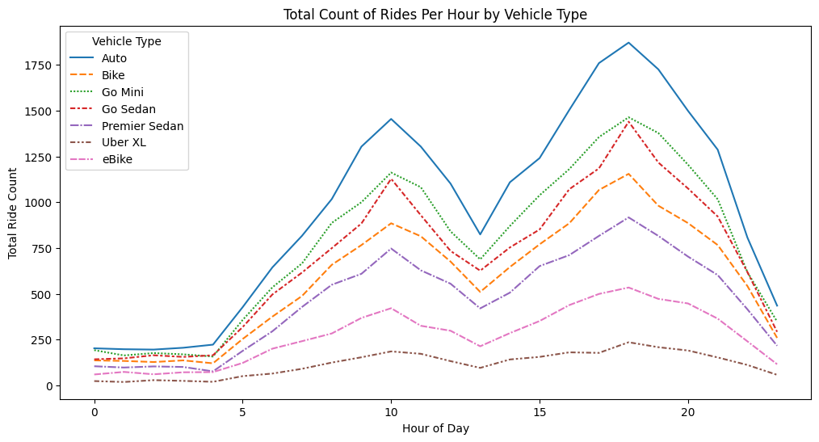

## 7) Recommendations to Stakeholders

### a) Ride Cancellation Recommendation

After reclassifying the cancellation reasons to the correct driver/customer, we can now see which factors most strongly influence ride cancellations. For customers, having sick or health related issues and having too many people in the car represent the largest share of customer-initiated cancellations. For drivers, personal & car related issues are the top driver-initiated cancellations. Any “customer related issue” we cannot classify who’s cancellation it belongs to therefore we categorize it as neither driver or customer-initiated.

For the stakeholders, or Uber management, in order to bring these cancellation rates down, I would strongly recommend having the customer answer questions on their health status to allow the driver to see the their input to decide whether or not to accept the job ticket. Otherwise, they can provide clearer in-app options for health-related adjustments, as well as flexible rescheduling.

This also goes for the drivers, where they can input the status of the car, allowing customers to see it’s quality before making a transaction.

### b) Customer Rating Recommendation

Although the customer rating analysis demonstrated weak correlations between ratings and other measurable ride metrics, there are still clear patterns we found that stakeholders can take note of. Ratings throughout the night (12am-5am) exhibit high volatility, mainly due to lower demand. It’s recommended that costs the cost for customers remain at a low to increase demand, while providing incentives for drivers to increase availability throughout the night. Late night safety can also be worry on both ends, therefore it’s recommended to implement any late-night safety/comfort prompts for customers and drivers.

Additionally, low demand vehicle types are shown to have higher volatility, so stakeholders should treat these categories with special attention in customer satisfaction monitoring and adjust performance evaluations to account for lower sample sizes.

Lastly, the average rating remains at a consistent 4.4/5 throughout the year, indicating a long-term satisfaction by customers. Any rideshare competitors or investors should take note of this comparable statistic and determine their strategic position relative to Uber’s performance.

## 8) Conclusion

Across both analyses, the primary opportunities in Uber’s growth is not in focusing on any specific metric, but instead the quality of service and user experience. Over 25% of rides were left incomplete and/or cancelled, so by focusing on clearer communication between drivers and customers, improving late night service quality, and increasing the overall market costs for both parties, we can improve overall efficiency within the business for the long run.